# Exercise #3

Fortgeschrittene Statistische Software für NF

Heeso Park (11929786)  
2024-06-07

## General Remarks

- You can submit your solutions in teams of up to 3 students.
- Include all your team-member’s names and student numbers (Martrikelnummern) in the `authors` field.
- Please use the exercise template document to work on and submit your results.
- Use a level 2 heading for each new exercise and answer each subtask next to it’s bullet point or use a new level 3 heading if you want.
- Always render the R code for your solutions and make sure to include the resulting data in your rendered document.
  - Make sure to not print more than 10 rows of data (unless specifically instructed to).
- Always submit both the rendered document(s) as well as your source Rmarkdown document. Submit the files separately on moodle, **not** as a zip archive.

## Exercise 1: Initializing git (4 Points)

For this whole exercise sheet we will be tracking all our changes to it in git.

1. Start by initializing a new R project with git support, called `2024-exeRcise-sheet-3`. If you forgot how to do this, you can follow this [guide](https://malikaihle.github.io/Introduction-RStudio-Git-GitHub/rstudio_project.html).
2. Commit the files generated by Rstudio.
3. For all of the following tasks in this exercise sheet we ask you to always commit your changes after finishing each subtask e.g. create a commit after task *1d*, *1e* etc.

> Note: This applies only to answers that have text or code as their answer. If you complete tasks in a different order or forget to commit one, this is no problem. If you change your answers you can just create multiple commits to track the changes.
4. Name 2 strengths and 2 weaknesses of git. (Don’t forget to create a commit after this answer, see *1c*)
   - **Strengths**:
     - Very hard to lose files with git, as it is designed to track changes to files and directories. This makes it very easy to revert to a previous version of a file or directory if something goes wrong.
     - Git is very fast and efficient. It is designed to handle large projects and is very good at managing changes to the codebase. This makes it a great tool for teams working on large projects.
   - **Weaknesses**:
     - Git can be complex to use. It has a lot of features and options that can be overwhelming for new users. This can make it hard to use git effectively and can lead to mistakes if you are not careful.
     - Struggles with binary (i.e. non-text) files and large files. Git is designed to track changes to text files, so it can struggle with binary files like images, videos, and executables. This can make it hard to track changes to these files and can lead to problems when working with them in git.
5. Knit this exercise sheet. Some new files will automatically be generated when knitting the sheet e.g. the HTML page. Ignore these files, as we only want to track the source files themselves.

## Exercise 2: Putting your Repository on GitHub (3.5 Points)

For this task you will upload your solution to GitHub.

1. Create a new repository on GitHub in your account named `exeRcise-sheet-3`. Make sure you create a **public repository** so we are able to see it for grading. Add the link to the repository below: https://github.com/heeso1747/exeRcise-sheet-3/tree/main
2. Push your code to this new repository by copying and executing the snippet on github listed under `…or push an existing repository from the command line`.
3. Regularly push your latest changes to GitHub again and especially do so when you are finished with this sheet.

## Exercise 3: Baby-Names in Munich (3.5 Points)

Download the latest open datasets on given names (“Vornamen”) from the open data repository of the city of Munich for the years `2023` and `2022`.

Link: https://opendata.muenchen.de/dataset/vornamen-von-neugeborenen

1. Download the data for both years and track it in git. For small datasets like these adding them to git is not a problem.
2. Load the data for both years into R. Check the type of the count variable (“Anzahl”) and look into the data to determine why it is not numeric? Fix the problem in an appropriate manner, it is OK if some of the counts are inaccurate because of this. Explain your solution and the repercussions.

```r
library(readr)

# Load the data for 2022
vornamen_2022 <- read_csv("vornamen_2022.csv")

# Load the data for 2023
vornamen_2023 <- read_csv("vornamen_2023.csv")

# Check the type of the count variable
str(vornamen_2022)
```

```
spc_tbl_ [4,390 × 3] (S3: spec_tbl_df/tbl_df/tbl/data.frame)
 $ Vorname   : chr [1:4390] "Emilia" "Emma" "Mia" "Sophia" ...
 $ Anzahl    : chr [1:4390] "103" "101" "93" "78" ...
 $ Geschlecht: chr [1:4390] "w" "w" "w" "w" ...
 - attr(*, "spec")=
  .. cols(
  ..   Vorname = col_character(),
  ..   Anzahl = col_character(),
  ..   Geschlecht = col_character()
  .. )
 - attr(*, "problems")=<externalptr>
```

```r
str(vornamen_2023)
```

```
spc_tbl_ [4,289 × 3] (S3: spec_tbl_df/tbl_df/tbl/data.frame)
 $ Vorname   : chr [1:4289] "Leon" "Maximilian" "Emilia" "Paul" ...
 $ Anzahl    : chr [1:4289] "107" "105" "89" "89" ...
 $ Geschlecht: chr [1:4289] "m" "m" "w" "m" ...
 - attr(*, "spec")=
  .. cols(
  ..   Vorname = col_character(),
  ..   Anzahl = col_character(),
  ..   Geschlecht = col_character()
  .. )
 - attr(*, "problems")=<externalptr>
```

- Given that the ‘Anzahl’ variable was loaded as a string (chr) type, it likely contains characters other than numbers. For example, there may be commas (,) between numbers, or special characters that indicate missing values.
- To fix this, we can remove all non-numeric characters from the ‘Anzahl’ variable and convert it to a numeric type.

```r
# Remove all non-numeric characters from the 'Anzahl' variable
vornamen_2022$Anzahl <- as.numeric(gsub("[^0-9]", "", vornamen_2022$Anzahl))
vornamen_2023$Anzahl <- as.numeric(gsub("[^0-9]", "", vornamen_2023$Anzahl))

# Convert the 'Anzahl' variable to a numeric type
vornamen_2022$Anzahl <- as.numeric(vornamen_2022$Anzahl)
vornamen_2023$Anzahl <- as.numeric(vornamen_2023$Anzahl)

# Check the type of the count variable
str(vornamen_2022)
```

```
spc_tbl_ [4,390 × 3] (S3: spec_tbl_df/tbl_df/tbl/data.frame)
 $ Vorname   : chr [1:4390] "Emilia" "Emma" "Mia" "Sophia" ...
 $ Anzahl    : num [1:4390] 103 101 93 78 72 71 71 67 65 61 ...
 $ Geschlecht: chr [1:4390] "w" "w" "w" "w" ...
 - attr(*, "spec")=
  .. cols(
  ..   Vorname = col_character(),
  ..   Anzahl = col_character(),
  ..   Geschlecht = col_character()
  .. )
 - attr(*, "problems")=<externalptr>
```

```r
str(vornamen_2023)
```

```
spc_tbl_ [4,289 × 3] (S3: spec_tbl_df/tbl_df/tbl/data.frame)
 $ Vorname   : chr [1:4289] "Leon" "Maximilian" "Emilia" "Paul" ...
 $ Anzahl    : num [1:4289] 107 105 89 89 83 80 80 78 74 72 ...
 $ Geschlecht: chr [1:4289] "m" "m" "w" "m" ...
 - attr(*, "spec")=
  .. cols(
  ..   Vorname = col_character(),
  ..   Anzahl = col_character(),
  ..   Geschlecht = col_character()
  .. )
 - attr(*, "problems")=<externalptr>
```

3. Calculate the total number of babies born in Munich in 2022 and 2023. Which year had the bigger baby-boom?

```r
# Calculate the total number of babies born in Munich in 2022 and 2023
total_babies_2022 <- sum(vornamen_2022$Anzahl, na.rm = TRUE)
total_babies_2023 <- sum(vornamen_2023$Anzahl, na.rm = TRUE)

# Print the results
print(paste("Total babies born in 2022:", total_babies_2022))
```

```
[1] "Total babies born in 2022: 25199"
```

```r
print(paste("Total babies born in 2023:", total_babies_2023))
```

```
[1] "Total babies born in 2023: 24229"
```

- In 2022 had the bigger baby-boom with a total of 25,199 babies born, compared to 2023 with a total of 24,229 babies born.
4. Add a new column `year` to both datasets which holds the correct year for each.

```r
# Add a new column 'year' to both datasets
vornamen_2022$year <- 2022
vornamen_2023$year <- 2023

# Check the datasets
head(vornamen_2022, 5)
```

```
# A tibble: 5 × 4
  Vorname Anzahl Geschlecht  year
  <chr>    <dbl> <chr>      <dbl>
1 Emilia     103 w           2022
2 Emma       101 w           2022
3 Mia         93 w           2022
4 Sophia      78 w           2022
5 Anna        72 w           2022
```

```r
head(vornamen_2023, 5)
```

```
# A tibble: 5 × 4
  Vorname    Anzahl Geschlecht  year
  <chr>       <dbl> <chr>      <dbl>
1 Leon          107 m           2023
2 Maximilian    105 m           2023
3 Emilia         89 w           2023
4 Paul           89 m           2023
5 Noah           83 m           2023
```

5. Combine both datasets into one using `bind_rows()`.

```r
library(dplyr)

# Combine both datasets
vornamen_combined <- bind_rows(vornamen_2022, vornamen_2023)

# Check the combined dataset
head(vornamen_combined, 5)
```

```
# A tibble: 5 × 4
  Vorname Anzahl Geschlecht  year
  <chr>    <dbl> <chr>      <dbl>
1 Emilia     103 w           2022
2 Emma       101 w           2022
3 Mia         93 w           2022
4 Sophia      78 w           2022
5 Anna        72 w           2022
```

```r
# Check the unique years in the combined dataset
unique(vornamen_combined$year)
```

```
[1] 2022 2023
```

6. Combine the counts for same names to determine the most popular names across both years. Print out the top 10 names in a nicely formatted table for both years. Include a table caption.

```r
# install and load necessary packages
library(knitr)
# install.packages("kableExtra")
library(kableExtra)

# Combine the counts for same names and determine the 10 most popular names across both years
popular_names <- vornamen_combined %>%
  group_by(Vorname) %>%
  summarise(Total = sum(Anzahl, na.rm = TRUE)) %>%
  arrange(desc(Total)) %>%
  top_n(10, Total)

# Simple print out of the top 10 names
print(popular_names)
```

```
# A tibble: 10 × 2
   Vorname    Total
   <chr>      <dbl>
 1 Maximilian   209
 2 Emilia       192
 3 Leon         188
 4 Anton        181
 5 Emma         172
 6 Felix        166
 7 Mia          163
 8 Paul         161
 9 Noah         159
10 Jonas        158
```

```r
# Print out the top 10 names in a nicely formatted table including a table caption.
kable(popular_names, format = "html", caption = "Top 10 Most Popular Baby Names in 2022-2023") %>%
  kable_styling(bootstrap_options = c("striped", "hover"))
```

Table 1: Top 10 Most Popular Baby Names in 2022-2023

| Vorname | Total |
| --- | --- |
| Maximilian | 209 |
| Emilia | 192 |
| Leon | 188 |
| Anton | 181 |
| Emma | 172 |
| Felix | 166 |
| Mia | 163 |
| Paul | 161 |
| Noah | 159 |
| Jonas | 158 |

## Exercise 4: Open Analysis (4 points)

This exercise is a bit more open-ended. You can choose any dataset from [Our World in Data](https://ourworldindata.org/) and analyze it, while determining the research question yourself.

1. Go to https://github.com/owid/owid-datasets/tree/master/datasets and choose a dataset that interests you. You can have a look at https://ourworldindata.org/ to gather some inspiration.
2. Download the dataset and track it in git.

```r
# Load the data
life_expectancy <- read_csv("life_expectancy_oecd.csv")

# Check the structure of the dataset
str(life_expectancy)
```

```
spc_tbl_ [2,238 × 3] (S3: spec_tbl_df/tbl_df/tbl/data.frame)
 $ Entity                : chr [1:2238] "Australia" "Australia" "Australia" "Australia" ...
 $ Year                  : num [1:2238] 1960 1961 1962 1963 1964 ...
 $ Life Expectancy (OECD): num [1:2238] 70.9 71.2 71 71.1 70.7 71 70.8 71.2 70.9 71.1 ...
 - attr(*, "spec")=
  .. cols(
  ..   Entity = col_character(),
  ..   Year = col_double(),
  ..   `Life Expectancy (OECD)` = col_double()
  .. )
 - attr(*, "problems")=<externalptr>
```

3. Put the name / title of the dataset and a link to it below.
- Dataset Name: Life expectancy - OECD
- Link: https://github.com/owid/owid-datasets/tree/master/datasets/Life%20expectancy%20-%20OECD
4. Come up with a (research) question you want to answer with the data and briefly explain why you believe this is an interesting question within one sentence. It should be a question that can be answered with the dataset and using R.
- ** Research Question: ** Which OECD country had the highest growth rate in life expectancy?
  - This question helps to assess how effectively countries are improving their health systems in relation to public health and social development.
5. Use R to answer your chosen question.

```r
# Calculate initial and final life expectancy for each country
life_expectancy_summary <- life_expectancy %>%
  group_by(Entity) %>%
  summarise(Initial_Life_Expectancy = first(`Life Expectancy (OECD)`),
            Final_Life_Expectancy = last(`Life Expectancy (OECD)`),
            Growth_Rate = (Final_Life_Expectancy - Initial_Life_Expectancy) / Initial_Life_Expectancy * 100) %>%
  arrange(desc(Growth_Rate))

# Print the results
head(life_expectancy_summary, 5)
```

```
# A tibble: 5 × 4
  Entity    Initial_Life_Expectancy Final_Life_Expectancy Growth_Rate
  <chr>                       <dbl>                 <dbl>       <dbl>
1 China                        43.4                  76          75.1
2 India                        41.2                  68.3        65.8
3 Turkey                       48.3                  78          61.5
4 Indonesia                    48.7                  69.1        41.9
5 Brazil                       54.3                  74.7        37.6
```

```r
# Find the top 10 countries with the highest growth rate
top_countries <- life_expectancy_summary %>%
  top_n(10, Growth_Rate)

print(top_countries)
```

```
# A tibble: 10 × 4
   Entity     Initial_Life_Expecta…¹ Final_Life_Expectancy Growth_Rate
   <chr>                       <dbl>                 <dbl>       <dbl>
 1 China                        43.4                  76          75.1
 2 India                        41.2                  68.3        65.8
 3 Turkey                       48.3                  78          61.5
 4 Indonesia                    48.7                  69.1        41.9
 5 Brazil                       54.3                  74.7        37.6
 6 South Kor…                   62.3                  82.1        31.8
 7 Costa Rica                   60.6                  79.6        31.4
 8 Colombia                     56.8                  74.2        30.6
 9 Mexico                       57.5                  75          30.4
10 Portugal                     63.9                  81.2        27.1
# ℹ abbreviated name: ¹Initial_Life_Expectancy
```

- The country with the highest growth rate in life expectancy is China with a growth rate of 75.11%.
6. Create a meaningful plot / figure with the dataset. Make sure to provide a figure caption (via the chunk options / Rmarkdown) and correctly label the figure.

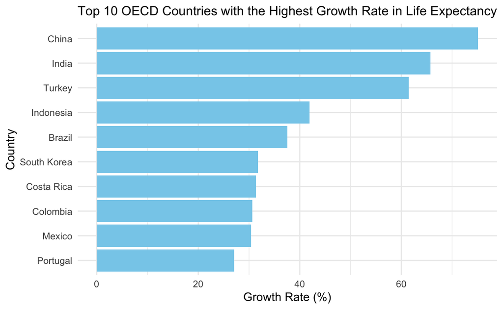

Figure 1: Top 10 OECD Countries with the Highest Growth Rate in Life Expectancy

```r
library(ggplot2)

# Create a bar plot to visualize the growth rate of life expectancy in OECD countries
ggplot(top_countries, aes(x = reorder(Entity, Growth_Rate), y = Growth_Rate)) +
  geom_bar(stat = "identity", fill = "skyblue") +
  coord_flip() +
  labs(title = "Top 10 OECD Countries with the Highest Growth Rate in Life Expectancy",
       x = "Country",
       y = "Growth Rate (%)") +
  theme_minimal() +
  theme(plot.title = element_text(size = 12))  # Adjust title size
```

- The figure 1 shows the top 10 OECD countries with the highest growth rate in life expectancy, with China leading the way.

## Final Note

Make sure to push all your commits and changes to GitHub before submittining the exercise sheet.